# Adani transmission stock

## 7. Momentum

- Momentum is a technical indicator used to measure the rate of change in a stock's price over a specific period. It helps identify the strength or weakness of a price trend and is commonly used to confirm trends and generate trading signals.
- The formula to calculate momentum is quite simple:

  $\text{Momentum} = \text{Close Price} - \text{Close Price}(n-\text{periods ago})$

  Where:
  - Close Price is the current closing price of the stock.
  - Close Price (n) periods ago is the closing price of the stock n periods (e.g., days) ago.
- The value of the momentum indicator can be positive or negative. A positive momentum value indicates upward price movement, while a negative momentum value indicates downward price movement.
- Traders often use a specific lookback period (n) when calculating momentum, such as 14 or 20 days, depending on their trading strategy and timeframe.

```python
# Calculate the momentum
n_periods = 10  # Number of periods for momentum calculation
adani_df3['Momentum'] = adani_df3['Close'] - adani_df3['Close'].shift(n_periods)

# Print the DataFrame with momentum values
adani_df3.head()
```

| Date | Open | High | Low | Close | Adj Close | Volume | rolling_mean | rolling_std | Momentum |
| --- | --- | --- | --- | --- | --- | --- | --- | --- | --- |
| 2022-01-03 | 1735.000000 | 1755.0 | 1710.000000 | 1731.099976 | 1731.099976 | 32602 | NaN | NaN | NaN |
| 2022-01-04 | 1731.099976 | 1775.0 | 1700.000000 | 1754.949951 | 1754.949951 | 42498 | NaN | NaN | NaN |
| 2022-01-05 | 1706.099976 | 1780.5 | 1706.099976 | 1761.050049 | 1761.050049 | 54105 | NaN | NaN | NaN |
| 2022-01-06 | 1730.000000 | 1770.0 | 1710.000000 | 1760.050049 | 1760.050049 | 51023 | NaN | NaN | NaN |
| 2022-01-07 | 1740.099976 | 1780.0 | 1721.849976 | 1776.000000 | 1776.000000 | 64894 | NaN | NaN | NaN |

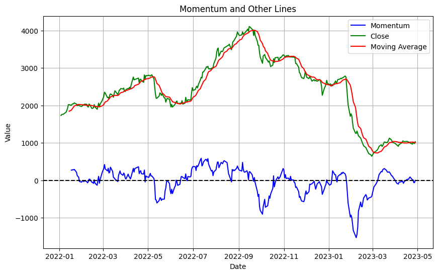

```python
# Create a figure and axis object
fig, ax = plt.subplots(figsize=(10, 6))

# Plotting the Momentum
plt.plot(adani_df3.index, adani_df3['Momentum'], label='Momentum', color='blue')

# Plotting the Close Price
plt.plot(adani_df3.index, adani_df3['Close'], label='Close', color='green')

# Plotting the Moving Average
plt.plot(adani_df3.index, adani_df3['rolling_mean'], label='Moving Average', color='red')

# Add grid lines
plt.grid(True)

# Add a horizontal line at y=0
plt.axhline(y=0, color='black', linestyle='--')

# Add labels and title
plt.xlabel('Date')
plt.ylabel('Value')
plt.title('Momentum and Other Lines')
plt.legend()

# Display the plot
plt.show()
```

## 8. Exponential Moving Average

- Exponential Moving Average (EMA) is a commonly used smoothing technique in time series analysis.
- It is similar to the simple moving average (SMA), but it assigns more weightage to recent data points.
- The EMA is calculated by applying a smoothing factor to the previous EMA value and adding a fraction of the current value.
- The formula to calculate the EMA at time period t is:

  $\text{EMA}_t = (1 - \alpha) \times \text{EMA}_{t-1} + \alpha \times \text{Value}_t$

  Where:
  - $\text{EMA}_t$ is the EMA at time period $t$.
  - $\text{EMA}_{t-1}$ is the EMA at the previous time period $(t-1)$.
  - $\text{Value}_t$ is the value at time period $t$.
  - $\alpha$ is the smoothing factor that determines the weightage given to the current value.
    - It is usually chosen between $0$ and $1$, smaller values giving more weight to past values and larger values giving more weight to the current value.
    - A commonly used smoothing factor is 2 / (selected period + 1).
- **Step to follow:** To calculate the Exponential Moving Average (EMA), you can follow these steps:
  - Choose a period for the EMA, which determines the number of data points to consider for smoothing. For example, you may select a period of 10 days.
  - Calculate the initial SMA (Simple Moving Average) for the selected period. This can be done by taking the average of the closing prices over the specified period.
  - Choose a smoothing factor, often denoted as α (alpha), which determines the weight given to the current value versus the previous EMA. The value of α is usually between 0 and 1, with smaller values giving more weight to past values and larger values giving more weight to the current value. A commonly used smoothing factor is 2 / (selected period + 1).
  - Calculate the EMA for the next data point using the formula:

    $\text{EMA}_t = (\text{Value}_t - \text{EMA}_{t-1}) \times \alpha + \text{EMA}_{t-1}$

    where $\text{EMA}_t$ is the EMA at time period $t$, $\text{Value}_t$ is the value at time period $t$, and $\text{EMA}_{t-1}$ is the EMA at the previous time period $(t-1)$.
  - Repeat step 4 for each subsequent data point, using the previously calculated EMA as the EMA_{t-1} for the next calculation.

> **Simple Moving Average:** The Simple Moving Average (SMA) is a commonly used method for smoothing time series data and identifying trends. It is calculated by taking the average of a specified number of data points over a given period.

> Formula:

> $\text{SMA} = \frac{\text{Sum of data points for the specified period}}{\text{Number of data points in the specified period}}$

```python
adani_df4 = adani_df0.copy()

adani_df4.head()
```

| Date | Open | High | Low | Close | Adj Close | Volume |
| --- | --- | --- | --- | --- | --- | --- |
| 2022-01-03 | 1735.000000 | 1755.0 | 1710.000000 | 1731.099976 | 1731.099976 | 32602 |
| 2022-01-04 | 1731.099976 | 1775.0 | 1700.000000 | 1754.949951 | 1754.949951 | 42498 |
| 2022-01-05 | 1706.099976 | 1780.5 | 1706.099976 | 1761.050049 | 1761.050049 | 54105 |
| 2022-01-06 | 1730.000000 | 1770.0 | 1710.000000 | 1760.050049 | 1760.050049 | 51023 |
| 2022-01-07 | 1740.099976 | 1780.0 | 1721.849976 | 1776.000000 | 1776.000000 | 64894 |

```python
# Specify the window size for the SMA
window = 20

# Calculate the SMA using rolling mean
adani_df4['SMA'] = adani_df4['Close'].rolling(window).mean()
adani_df4.head()
```

| Date | Open | High | Low | Close | Adj Close | Volume | SMA |
| --- | --- | --- | --- | --- | --- | --- | --- |
| 2022-01-03 | 1735.000000 | 1755.0 | 1710.000000 | 1731.099976 | 1731.099976 | 32602 | NaN |
| 2022-01-04 | 1731.099976 | 1775.0 | 1700.000000 | 1754.949951 | 1754.949951 | 42498 | NaN |
| 2022-01-05 | 1706.099976 | 1780.5 | 1706.099976 | 1761.050049 | 1761.050049 | 54105 | NaN |
| 2022-01-06 | 1730.000000 | 1770.0 | 1710.000000 | 1760.050049 | 1760.050049 | 51023 | NaN |
| 2022-01-07 | 1740.099976 | 1780.0 | 1721.849976 | 1776.000000 | 1776.000000 | 64894 | NaN |

```python
# Specify the span for the EMA
span = 20

# Calculate the EMA using ewm
adani_df4['EMA'] = adani_df4['Close'].ewm(span=span, adjust=False).mean()

# Print the DataFrame with EMA

adani_df4.head(20)
```

| Date | Open | High | Low | Close | Adj Close | Volume | SMA | EMA |
| --- | --- | --- | --- | --- | --- | --- | --- | --- |
| 2022-01-03 | 1735.000000 | 1755.000000 | 1710.000000 | 1731.099976 | 1731.099976 | 32602 | NaN | 1731.099976 |
| 2022-01-04 | 1731.099976 | 1775.000000 | 1700.000000 | 1754.949951 | 1754.949951 | 42498 | NaN | 1733.371402 |
| 2022-01-05 | 1706.099976 | 1780.500000 | 1706.099976 | 1761.050049 | 1761.050049 | 54105 | NaN | 1736.007463 |
| 2022-01-06 | 1730.000000 | 1770.000000 | 1710.000000 | 1760.050049 | 1760.050049 | 51023 | NaN | 1738.297233 |
| 2022-01-07 | 1740.099976 | 1780.000000 | 1721.849976 | 1776.000000 | 1776.000000 | 64894 | NaN | 1741.887973 |
| 2022-01-10 | 1742.099976 | 1834.000000 | 1742.099976 | 1819.699951 | 1819.699951 | 68601 | NaN | 1749.298638 |
| 2022-01-11 | 1839.000000 | 1889.000000 | 1770.000000 | 1867.449951 | 1867.449951 | 100209 | NaN | 1760.551144 |
| 2022-01-12 | 1880.000000 | 1958.000000 | 1822.500000 | 1928.250000 | 1928.250000 | 108933 | NaN | 1776.522463 |
| 2022-01-13 | 1973.900024 | 2024.650024 | 1906.000000 | 2019.699951 | 2019.699951 | 143323 | NaN | 1799.682224 |
| 2022-01-14 | 1998.000000 | 2030.000000 | 1930.000000 | 2020.599976 | 2020.599976 | 55454 | NaN | 1820.722010 |
| 2022-01-17 | 1995.000000 | 2016.000000 | 1970.199951 | 2002.699951 | 2002.699951 | 78536 | NaN | 1838.053242 |
| 2022-01-18 | 2002.699951 | 2050.000000 | 1981.000000 | 2026.750000 | 2026.750000 | 81437 | NaN | 1856.024362 |
| 2022-01-19 | 2040.000000 | 2049.399902 | 1950.000000 | 2043.250000 | 2043.250000 | 47517 | NaN | 1873.855375 |
| 2022-01-20 | 2002.550049 | 2049.899902 | 1975.000000 | 2039.750000 | 2039.750000 | 48408 | NaN | 1889.654863 |
| 2022-01-21 | 2037.000000 | 2141.000000 | 1984.000000 | 2066.800049 | 2066.800049 | 82788 | NaN | 1906.525833 |
| 2022-01-24 | 2097.000000 | 2125.000000 | 1963.500000 | 2035.900024 | 2035.900024 | 85918 | NaN | 1918.847185 |
| 2022-01-25 | 1950.000000 | 2089.000000 | 1934.150024 | 1992.449951 | 1992.449951 | 198926 | NaN | 1925.856972 |
| 2022-01-27 | 2005.000000 | 2059.300049 | 1920.000000 | 2009.300049 | 2009.300049 | 94304 | NaN | 1933.803932 |
| 2022-01-28 | 2000.000000 | 2075.000000 | 1960.000000 | 1986.800049 | 1986.800049 | 231963 | NaN | 1938.851181 |
| 2022-01-31 | 2020.000000 | 2046.300049 | 1950.000000 | 1970.900024 | 1970.900024 | 153177 | 1930.672498 | 1941.903452 |

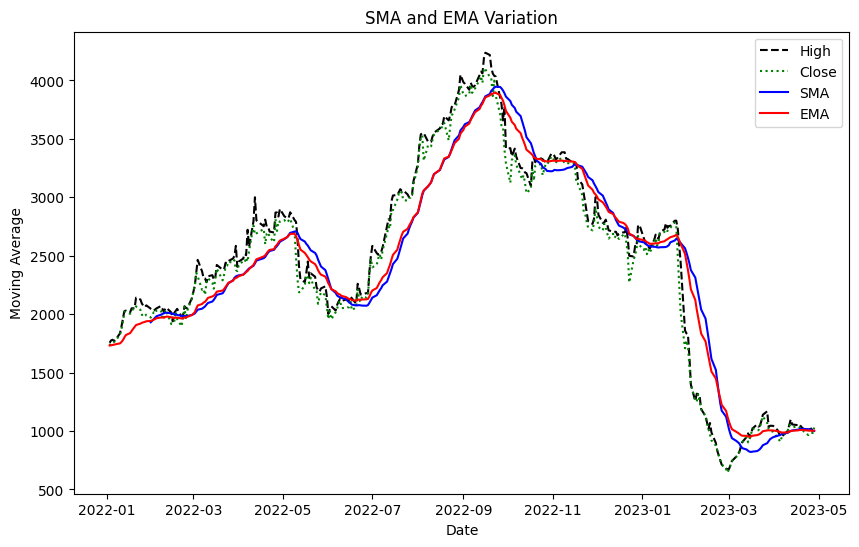

```python
# Create a figure and axis object
fig, ax = plt.subplots(figsize=(10, 6))

ax.plot(adani_df4.index, adani_df4['High'], label='High', color='black', linestyle = '--')
ax.plot(adani_df4.index, adani_df4['Close'], label='Close', color='green', linestyle = ':')
# Plot SMA
ax.plot(adani_df4.index, adani_df4['SMA'], label='SMA', color='blue')

# Plot EMA
ax.plot(adani_df4.index, adani_df4['EMA'], label='EMA', color='red')

# Set the x-axis label
ax.set_xlabel('Date')

# Set the y-axis label
ax.set_ylabel('Moving Average')

# Set the title
ax.set_title('SMA and EMA Variation')

# Add a legend
ax.legend()

# Display the plot
plt.show()
```

## 9. Bollinger Bands

- Bollinger Bands are a popular technical analysis tool used to identify volatility and potential price reversal points in financial markets.
- The Bollinger Bands consist of three lines:
  - The middle band, which is typically a `Simple Moving Average (SMA)` over a specified period.
  - The upper band, which is calculated by adding a specified number of `standard deviations` to the middle band.
  - The lower band, which is calculated by subtracting a specified number of `standard deviations` from the middle band.
- The formula to calculate Bollinger Bands is as follows:
  - Middle Band (MB) = SMA (Simple Moving Average)
  - Upper Band (UB) = MB + (k * Standard Deviation)
  - Lower Band (LB) = MB - (k * Standard Deviation)

  Where:
  - k is the number of standard deviations to use (typically set to 2)
  - Standard Deviation is calculated as the square root of the mean of squared differences between each data point and the mean of the specified period.
- The Bollinger Bands help traders identify periods of high or low volatility and potential price reversals.
- When the price touches or crosses the upper band, it may indicate an overbought condition, suggesting a potential price decrease.
- Conversely, when the price touches or crosses the lower band, it may indicate an oversold condition, suggesting a potential price increase.

```python
# Specify the period and the number of standard deviations
period = 20
num_std = 2

# Calculate the middle band (MB) using a Simple Moving Average (SMA)
adani_df4['MB'] = adani_df4['Close'].rolling(window=period).mean()

# Calculate the standard deviation (SD) using the same period
adani_df4['SD'] = adani_df4['Close'].rolling(window=period).std()

# Calculate the upper band (UB) and lower band (LB)
adani_df4['UB'] = adani_df4['MB'] + (num_std * adani_df4['SD'])
adani_df4['LB'] = adani_df4['MB'] - (num_std * adani_df4['SD'])

adani_df4.head()
```

| Date | Open | High | Low | Close | Adj Close | Volume | SMA | EMA | MB | SD | UB | LB |
| --- | --- | --- | --- | --- | --- | --- | --- | --- | --- | --- | --- | --- |
| 2022-01-03 | 1735.000000 | 1755.0 | 1710.000000 | 1731.099976 | 1731.099976 | 32602 | NaN | 1731.099976 | NaN | NaN | NaN | NaN |
| 2022-01-04 | 1731.099976 | 1775.0 | 1700.000000 | 1754.949951 | 1754.949951 | 42498 | NaN | 1733.371402 | NaN | NaN | NaN | NaN |
| 2022-01-05 | 1706.099976 | 1780.5 | 1706.099976 | 1761.050049 | 1761.050049 | 54105 | NaN | 1736.007463 | NaN | NaN | NaN | NaN |
| 2022-01-06 | 1730.000000 | 1770.0 | 1710.000000 | 1760.050049 | 1760.050049 | 51023 | NaN | 1738.297233 | NaN | NaN | NaN | NaN |
| 2022-01-07 | 1740.099976 | 1780.0 | 1721.849976 | 1776.000000 | 1776.000000 | 64894 | NaN | 1741.887973 | NaN | NaN | NaN | NaN |

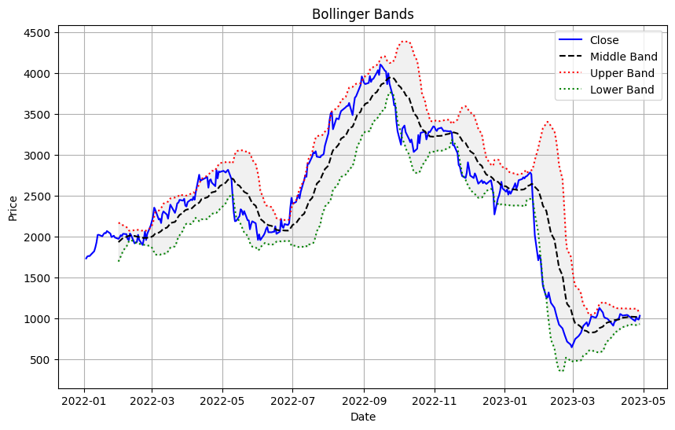

```python
# Plot the closing prices
plt.figure(figsize=(10, 6))
plt.plot(adani_df4.index, adani_df4['Close'], label='Close', color='blue')

# Plot the middle band (MB)
plt.plot(adani_df4.index, adani_df4['MB'], label='Middle Band', color='black', linestyle = '--')

# Plot the upper band (UB)
plt.plot(adani_df4.index, adani_df4['UB'], label='Upper Band', color='red', linestyle = ':')

# Plot the lower band (LB)
plt.plot(adani_df4.index, adani_df4['LB'], label='Lower Band', color='green', linestyle = ':')


# Shade the area between UB and LB
plt.fill_between(adani_df4.index, adani_df4['UB'], adani_df4['LB'], color='lightgray', alpha=0.3)


# Add labels and title
plt.xlabel('Date')
plt.ylabel('Price')
plt.title('Bollinger Bands')
plt.grid(True)

# Add legend
plt.legend()

# Display the plot
plt.show()
```

## 10. Moving average convergence divergence (MACD)

- The Moving Average Convergence Divergence (MACD) is a popular technical indicator used in financial analysis to identify potential trend reversals, generate buy and sell signals, and assess the overall momentum of an asset's price. The MACD is calculated using the following formula:
  - MACD Line (MACD): EMA(12-period) - EMA(26-period)
  - Signal Line: EMA(9-period) of the MACD Line
  - MACD Histogram: MACD Line - Signal Line $\Rightarrow$ It signifies the strength and momentum of the price movement.

  Here's a breakdown of the components:
  - MACD Line (MACD): It is the difference between the 12-period Exponential Moving Average (EMA) and the 26-period EMA. It captures the short-term and long-term trend of the price.
  - Signal Line: It is the 9-period EMA of the MACD Line. The Signal Line acts as a trigger line and helps identify potential buy and sell signals.
  - MACD Histogram: It represents the difference between the MACD Line and the Signal Line. The histogram visually shows the convergence and divergence of the MACD Line and the Signal Line, indicating the strength of the price momentum.

```python
# Copying the original dataframe

adani_df5 = adani_df0.copy()

# Calculate MACD
short_period = 12
long_period = 26
signal_period = 9

# Calculate the short-term EMA
ema_short = adani_df5['Close'].ewm(span=short_period, adjust=False).mean()

# Calculate the long-term EMA
ema_long = adani_df5['Close'].ewm(span=long_period, adjust=False).mean()

# Calculate MACD Line
macd_line = ema_short - ema_long

# Calculate Signal Line
signal_line = macd_line.ewm(span=signal_period, adjust=False).mean()

# MACD histogram line
macd_histogram = macd_line - signal_line


# Add MACD Line and Signal Line to DataFrame
adani_df5['MACD Line'] = macd_line
adani_df5['Signal Line'] = signal_line
adani_df5['MACD Histogram'] = macd_histogram

adani_df5.head()
```

| Date | Open | High | Low | Close | Adj Close | Volume | MACD Line | Signal Line | MACD Histogram |
| --- | --- | --- | --- | --- | --- | --- | --- | --- | --- |
| 2022-01-03 | 1735.000000 | 1755.0 | 1710.000000 | 1731.099976 | 1731.099976 | 32602 | 0.000000 | 0.000000 | 0.000000 |
| 2022-01-04 | 1731.099976 | 1775.0 | 1700.000000 | 1754.949951 | 1754.949951 | 42498 | 1.902562 | 0.380512 | 1.522050 |
| 2022-01-05 | 1706.099976 | 1780.5 | 1706.099976 | 1761.050049 | 1761.050049 | 54105 | 3.858109 | 1.076032 | 2.782078 |
| 2022-01-06 | 1730.000000 | 1770.0 | 1710.000000 | 1760.050049 | 1760.050049 | 51023 | 5.266494 | 1.914124 | 3.352370 |
| 2022-01-07 | 1740.099976 | 1780.0 | 1721.849976 | 1776.000000 | 1776.000000 | 64894 | 7.582273 | 3.047754 | 4.534519 |

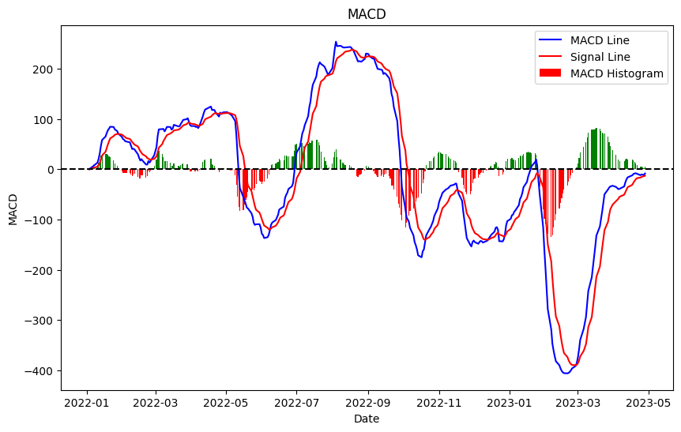

```python
# Plot MACD Line, Signal Line, and Histogram
plt.figure(figsize=(10, 6))
plt.plot(adani_df5.index, adani_df5['MACD Line'], label='MACD Line', color='blue')
plt.plot(adani_df5.index, adani_df5['Signal Line'], label='Signal Line', color='red')
plt.bar(adani_df5.index, adani_df5['MACD Histogram'], label='MACD Histogram', color=np.where(adani_df5['MACD Histogram'] > 0, 'green', 'red'))

# Add zero line
plt.axhline(y=0, color='black', linestyle='--')

# Customize the plot
plt.title('MACD')
plt.xlabel('Date')
plt.ylabel('MACD')
plt.legend()

# Show the plot
plt.show()
```

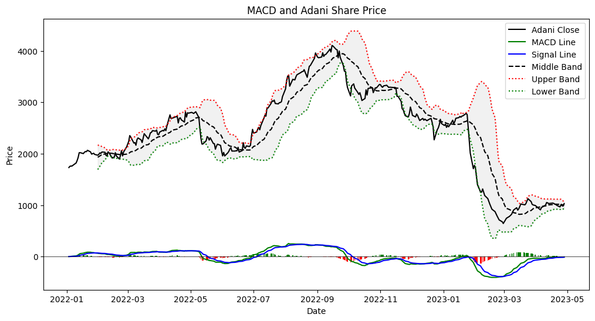

```python
# We can draw MACD line along with the CLosing price along with the Bollinger bands.
plt.figure(figsize=(12, 6))
plt.plot(adani_df5.index, adani_df5['Close'], label='Adani Close', color='black')
plt.plot(adani_df5.index, adani_df5['MACD Line'], label='MACD Line', color='green')
plt.plot(adani_df5.index, adani_df5['Signal Line'], label='Signal Line', color='blue')
plt.bar(adani_df5.index, adani_df5['MACD Histogram'], color=np.where(adani_df5['MACD Histogram'] > 0, 'green', 'red'))

# Plot the middle band (MB)
plt.plot(adani_df4.index, adani_df4['MB'], label='Middle Band', color='black', linestyle = '--')
# Plot the upper band (UB)
plt.plot(adani_df4.index, adani_df4['UB'], label='Upper Band', color='red', linestyle = ':')
# Plot the lower band (LB)
plt.plot(adani_df4.index, adani_df4['LB'], label='Lower Band', color='green', linestyle = ':')
# Shade the area between UB and LB
plt.fill_between(adani_df4.index, adani_df4['UB'], adani_df4['LB'], color='lightgray', alpha=0.3)


plt.axhline(y=0, color='black', linewidth=0.5)
plt.title('MACD and Adani Share Price')
plt.xlabel('Date')
plt.ylabel('Price')
plt.legend()
plt.show()
```

## 11. Stochastic (STO) & Relative Strength Index (RSI)

Stochastic (STO) and Relative Strength Index (RSI) are popular technical indicators used in financial analysis to evaluate the momentum and strength of price movements in a security.

### 1. Stochastic (STO)

- The Stochastic oscillator measures the closing price relative to the high-low range over a specified period.

  $\% \text{K} = \left(\frac{\text{Current Close} - \text{Lowest Low}}{\text{Highest High} - \text{Lowest Low}}\right) \times 100$

  $\%\text{D} = \text{Simple moving average of} ~\%\text{K}~ \text{over a specified period}$

  Where:
  - Current Close: The most recent closing price.
  - Lowest Low: The lowest low price over a specified period.
  - Highest High: The highest high price over a specified period.
  - %K: The current value of the Stochastic oscillator.
  - %D: The moving average of %K over a specified period.

### 2. Relative Strength Index (RSI):

- The Relative Strength Index measures the magnitude of recent price changes to assess overbought or oversold conditions in a security.

  $\text{RSI} = 100 - \frac{100}{1 + RS}$

  $\text{RS} = \frac{\text{Average gain over a specified period}}{\text{Average loss over a specified period}}$

  Where:
  - Average gain: The average price increase over a specified period.
  - Average loss: The average price decrease over a specified period.
  - RS: The relative strength calculated as the ratio of the average gain to the average loss.
  - RSI: The current value of the Relative Strength Index.

> **Note:** The specific period and parameters used in the calculations can vary based on individual preferences and trading strategies.

> Please note that these formulas provide a basic understanding of how STO and RSI are calculated. There might be variations or different smoothing techniques used in different implementations.

```python
# copying the original dataframe

adani_df6 = adani_df0.copy()
```

We can calculate STO as:

```
# Calculate Stochastic Oscillator (STO)
def calculate_stochastic(data, k_period=14, d_period=3):
    highest_high = data['High'].rolling(window=k_period).max()
    lowest_low = data['Low'].rolling(window=k_period).min()
    k = ((data['Close'] - lowest_low) / (highest_high - lowest_low)) * 100
    d = k.rolling(window=d_period).mean()
    return k, d
```

We can calculate RSI as:

```
# Calculate RSI
def calculate_rsi(data, period=14):
    close_delta = data['Close'].diff()
    gain = close_delta.where(close_delta > 0, 0)
    loss = -close_delta.where(close_delta < 0, 0)
    avg_gain = gain.rolling(window=period).mean()
    avg_loss = loss.rolling(window=period).mean()
    rs = avg_gain / avg_loss
    rsi = 100 - (100 / (1 + rs))
    return rsi
```

```python
highest_high = adani_df6['High'].rolling(14).max()
lowest_low = adani_df6['Low'].rolling(14).min()
adani_df6['%K'] = (adani_df6['Close']-lowest_low)*100/(highest_high-lowest_low)
adani_df6['%D'] = adani_df6['%K'].rolling(3).mean() # check the rolling window,
```

```python
adani_df6.head()
```

[output not shown]

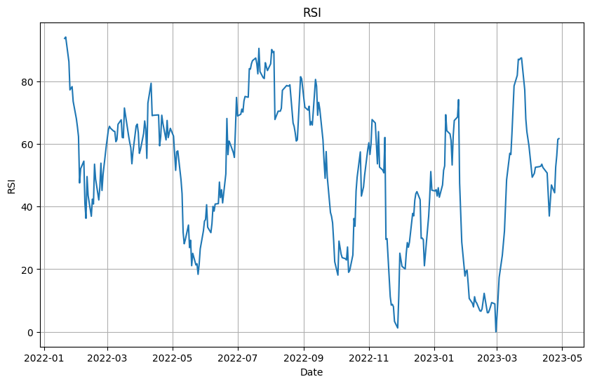

```python
plt.figure(figsize=(10, 6))
plt.plot(adani_df6.index, adani_df6['RSI'])
plt.title('RSI')
plt.xlabel('Date')
plt.ylabel('RSI')
plt.grid(True)
plt.show()
```

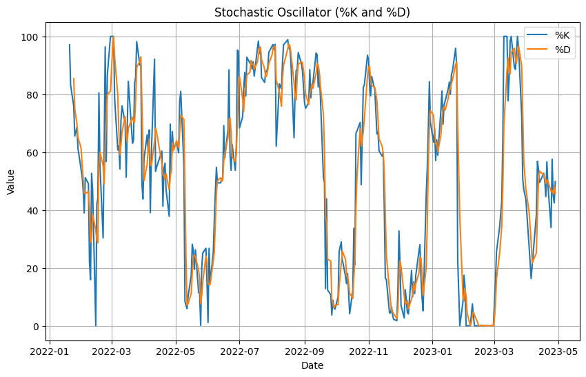

```python
plt.figure(figsize=(10, 6))
plt.plot(adani_df6.index, adani_df6['%K'], label='%K')
plt.plot(adani_df6.index, adani_df6['%D'], label='%D')
plt.title('Stochastic Oscillator (%K and %D)')
plt.xlabel('Date')
plt.ylabel('Value')
plt.legend()
plt.grid(True)
plt.show()
```

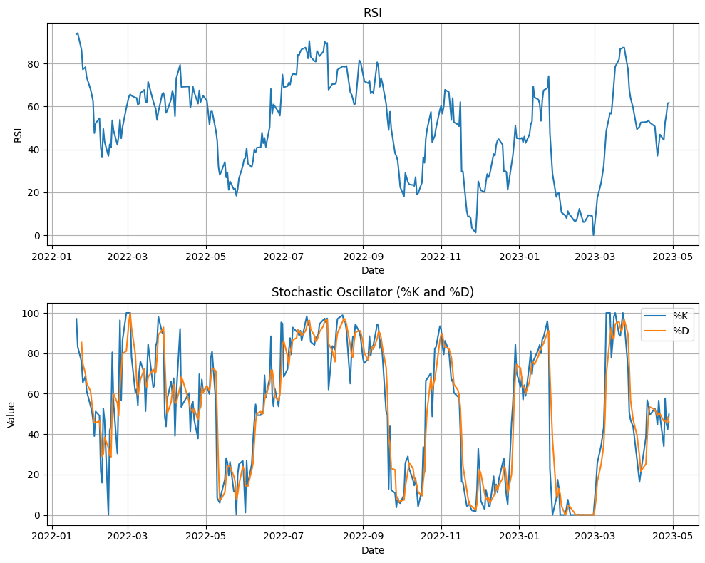

```python
fig, (ax1, ax2) = plt.subplots(2, 1, figsize=(10, 8))

ax1.plot(adani_df6.index, adani_df6['RSI'])
ax1.set_title('RSI')
ax1.set_xlabel('Date')
ax1.set_ylabel('RSI')
ax1.grid(True)

ax2.plot(adani_df6.index, adani_df6['%K'], label='%K')
ax2.plot(adani_df6.index, adani_df6['%D'], label='%D')
ax2.set_title('Stochastic Oscillator (%K and %D)')
ax2.set_xlabel('Date')
ax2.set_ylabel('Value')
ax2.legend()
ax2.grid(True)

plt.tight_layout()
plt.show()
```

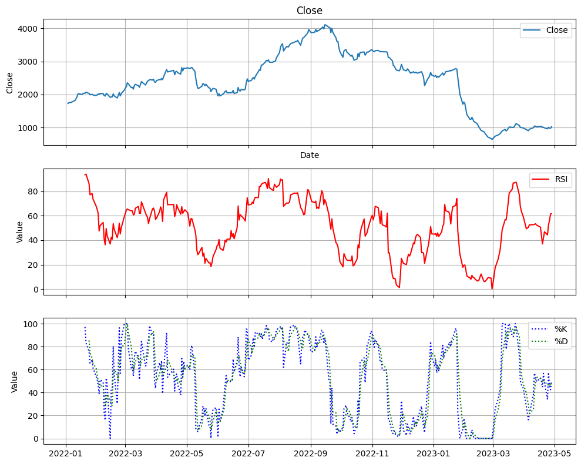

```python
# Create a figure with two subplots
fig, (ax1, ax2, ax3) = plt.subplots(3, 1, figsize=(10, 8), sharex=True)

# Plot Close in the second subplot
ax1.plot(adani_df6.index, adani_df6['Close'], label='Close')
ax1.set_xlabel('Date')
ax1.set_ylabel('Close')
ax1.set_title('Close')
ax1.legend()
ax1.grid(True)

# Plot RSI, %K, and %D in the first subplot
ax2.plot(adani_df6.index, adani_df6['RSI'], label='RSI', color = 'red')
ax2.grid(True)
ax2.set_ylabel('Value')
ax2.legend()

ax3.plot(adani_df6.index, adani_df6['%K'], label='%K', color = 'blue', linestyle =  ':')
ax3.plot(adani_df6.index, adani_df6['%D'], label='%D', color = 'green', linestyle = ':')
ax3.set_ylabel('Value')
ax3.legend()
ax3.grid(True)

# Adjust spacing between subplots
plt.tight_layout()

# Display the plot
plt.show()
```

## Reference

- https://github.com/arunsinp/Data-analysis-projects
- https://github.com/arunsinp/Data-analysis-projects/tree/main/EDA_dbbank
- https://github.com/arunsinp/Data-analysis-projects/blob/main/EDA_dbbank/Statistics.ipynb